# Neuroendrocine prostate cancer (NEPC)

Taehoon Ha, Diane Li, Lingchen Lou

### NEPC

The goal of this project is to identify the clinical characteristics and molecular profiles of responding patients (those who did not have disease progression at 3 months) to define distinct cohorts most likely to benefit. Of particular interest is whether there are differences in outcome (3-month progression-free survival) and other variables between patients with neuroendrocine prostate cancer (NEPC) and patients who have a non-NEPC metastatic prostate cancer.

In particular, your analysis should include (but not be limited to) the answers to the following questions:

1. What is the observed 3-month progression free survival rate for men with metastatic prostate cancer treated with alisertib?
2. What variables are associated with 3-month progression status?
3. Is there an association between gene abnormalities and 3 month progression status?
4. Are there different gene abnormalities and other variables associated with NEPC?

### Background

Sixty men were treated with alisertib 50 mg twice daily for 7 days every 21 days. Eligibility included metastatic prostate cancer. Pretreatment biopsies were evaluated by whole exome and RNA-seq to determine gene abnormalities. There is some evidence that NEPC is an aggressive variant of prostate cancer that may develop as a mechanism of treatment resistance and it was felt that alisertib would benefit these patients most. In the lab, it was found that alisertib inhibits the interaction between N-myc (MYCN) and its stabilizing factor Aurora-A (AURKA), inhibiting N-myc signaling, and suppressing tumor growth.

#### Data

The variables of interest include the following: `Gleason score`, `PSA at baseline (ng/mL)`, `number of prior systemic treatments`, `NEPC`, `time from PCA diagnosis to starting alisertib`, `visceral disease`, `elevated LDH`, `progression-free at 3 months`, `RB1` status, `TP53` status, `PTEN` status, `BRAC2` status, `AR` status, `AURKA` status, `MYCN` status.

The data and variables codes are available in an Excel file.

| Variable Name | Definition |
| --- | --- |
| rc_id | Patient ID |
| gleason_biop | Baseline Gleason score |
| psa | Baseline prostate specific antigen () |
| priorTherapies_numLines | Number of cancer therapy lines prior to baseline |
| NEPC | Indicator of neuroendocrine prostate cancer |
| diagToC1d1_mo | Months from initial prostate cancer diagnosis to study baseline |
| visceralDisease | Visceral disease at baseline |
| screenLabs_ldhAbnormal | Baseline LDH abnormal |
| progressed_3mo | Progression status at 3 months |
| RB1 $\cdots$ mycn_mutation | Mutation (1: Yes, 0: No) |

### Read the data set

```r
dat_nepc <- readxl::read_xlsx('group01_dataNEPC.xlsx', sheet = 1, na = "")
dat_nepc$gleason_biop <- as.numeric(dat_nepc$gleason_biop)
dat_nepc$NEPC <- as.factor(dat_nepc$NEPC)
dat_nepc$diagToC1d1_mo <- as.numeric(dat_nepc$diagToC1d1_mo)
dat_nepc$visceralDisease <- as.factor(dat_nepc$visceralDisease)
dat_nepc$screenLabs_ldhAbnormal <- as.factor(as.logical(dat_nepc$screenLabs_ldhAbnormal))
dat_nepc$progressed_3mo <- as.factor(dat_nepc$progressed_3mo)
dat_nepc$rb1_mutation <- as.factor(as.numeric(dat_nepc$rb1_mutation))
dat_nepc$tp53_mutation <- as.factor(as.numeric(dat_nepc$tp53_mutation))
dat_nepc$pten_mutation <- as.factor(as.numeric(dat_nepc$pten_mutation))
dat_nepc$brca2_mutation <- as.factor(as.numeric(dat_nepc$brca2_mutation))
dat_nepc$ar_mutation <- as.factor(as.numeric(dat_nepc$ar_mutation))
dat_nepc$aurka_mutation <- as.factor(as.numeric(dat_nepc$aurka_mutation))
dat_nepc$mycn_mutation <- as.factor(as.numeric(dat_nepc$mycn_mutation))
```

### Rename the data

```r
dat_nepc <- dat_nepc %>%
  rename(gleason = gleason_biop,
         prtherapy = priorTherapies_numLines,
         intdiag = diagToC1d1_mo,
         visceral = visceralDisease,
         LDHab = screenLabs_ldhAbnormal,
         prog3mon = progressed_3mo,
         rb1 = rb1_mutation,
         tp53 = tp53_mutation,
         pten = pten_mutation,
         brca2 = brca2_mutation,
         ar = ar_mutation,
         aurka = aurka_mutation,
         mycn = mycn_mutation)
```

### Check NAs in the data set

```r
#Summary of NA's in dataset
summary(dat_nepc)
```

```
##     rc_id              gleason            psa            prtherapy
##  Length:60          Min.   : 6.000   Min.   :  0.008   Min.   :0.000
##  Class :character   1st Qu.: 7.000   1st Qu.:  0.130   1st Qu.:1.000
##  Mode  :character   Median : 8.000   Median :  1.075   Median :2.000
##                     Mean   : 8.044   Mean   : 37.008   Mean   :2.317
##                     3rd Qu.: 9.000   3rd Qu.: 16.530   3rd Qu.:3.000
##                     Max.   :10.000   Max.   :514.200   Max.   :6.000
##                     NA's   :15
##   NEPC       intdiag         visceral   LDHab                prog3mon
##  No :22   Min.   :   3.934   No :19   FALSE:28   Did not progress:16
##  Yes:38   1st Qu.:  11.443   Yes:41   TRUE :29   Progressed      :44
##           Median :  44.230            NA's : 3
##           Mean   :  77.415
##           3rd Qu.:  88.098
##           Max.   :1313.443
##           NA's   :3
##    rb1       tp53      pten     brca2       ar      aurka      mycn
##  0   :44   0   :28   0   :43   0   :42   0   :42   0   :44   0   :44
##  NA's:16   1   :16   1   : 1   1   : 2   1   : 2   NA's:16   NA's:16
##            NA's:16   NA's:16   NA's:16   NA's:16
##
##
##
##
```

```r
dim(dat_nepc)
```

```
## [1] 60 16
```

```r
str(dat_nepc)
```

```
## Classes 'tbl_df', 'tbl' and 'data.frame':    60 obs. of  16 variables:
##  $ rc_id    : chr  "01-001" "01-002" "01-003" "01-005" ...
##  $ gleason  : num  7 NA 10 8 NA NA 10 7 7 9 ...
##  $ psa      : num  0.086 3.76 0.02 83 0.18 ...
##  $ prtherapy: num  3 1 2 1 2 0 1 3 2 2 ...
##  $ NEPC     : Factor w/ 2 levels "No","Yes": 1 2 2 2 2 2 2 1 2 2 ...
##  $ intdiag  : num  254.59 12.13 43.77 34.59 3.93 ...
##  $ visceral : Factor w/ 2 levels "No","Yes": 1 1 1 1 2 2 2 2 1 2 ...
##  $ LDHab    : Factor w/ 2 levels "FALSE","TRUE": 1 1 1 2 1 2 1 2 2 1 ...
##  $ prog3mon : Factor w/ 2 levels "Did not progress",..: 1 1 1 1 2 1 2 2 2 1 ...
##  $ rb1      : Factor w/ 1 level "0": 1 1 1 1 1 1 NA 1 1 1 ...
##  $ tp53     : Factor w/ 2 levels "0","1": 1 1 2 1 1 1 NA 2 1 2 ...
##  $ pten     : Factor w/ 2 levels "0","1": 1 1 1 1 1 1 NA 1 1 1 ...
##  $ brca2    : Factor w/ 2 levels "0","1": 1 2 1 1 1 1 NA 1 1 2 ...
##  $ ar       : Factor w/ 2 levels "0","1": 1 1 1 1 1 1 NA 1 1 1 ...
##  $ aurka    : Factor w/ 1 level "0": 1 1 1 1 1 1 NA 1 1 1 ...
##  $ mycn     : Factor w/ 1 level "0": 1 1 1 1 1 1 NA 1 1 1 ...
```

```r
na_count <-sapply(dat_nepc, function(y) sum(length(which(is.na(y)))))
na_count <- data.frame(na_count)
na_count <- rownames_to_column(na_count) %>%
  mutate(na_percent=round((na_count/nrow(dat_nepc))*100,1))

knitr::kable(na_count, col.names = c("Variable","Number of NAs", "%")) %>%
  kable_styling(full_width = F)
```

| Variable | Number of NAs | % |
| --- | --- | --- |
| rc_id | 0 | 0.0 |
| gleason | 15 | 25.0 |
| psa | 0 | 0.0 |
| prtherapy | 0 | 0.0 |
| NEPC | 0 | 0.0 |
| intdiag | 3 | 5.0 |
| visceral | 0 | 0.0 |
| LDHab | 3 | 5.0 |
| prog3mon | 0 | 0.0 |
| rb1 | 16 | 26.7 |
| tp53 | 16 | 26.7 |
| pten | 16 | 26.7 |
| brca2 | 16 | 26.7 |
| ar | 16 | 26.7 |
| aurka | 16 | 26.7 |
| mycn | 16 | 26.7 |

> - There are many missing values for gene abnoramlities. More then 1/4 of observations of each variable have missing values. This could cause a significant problem, especially in power to detect the significant difference.

### Check each variable one by one

1. Continuous variables of non-gene abnormalities: `gleason`, `psa`, `prtherapy`, and `intdiag`

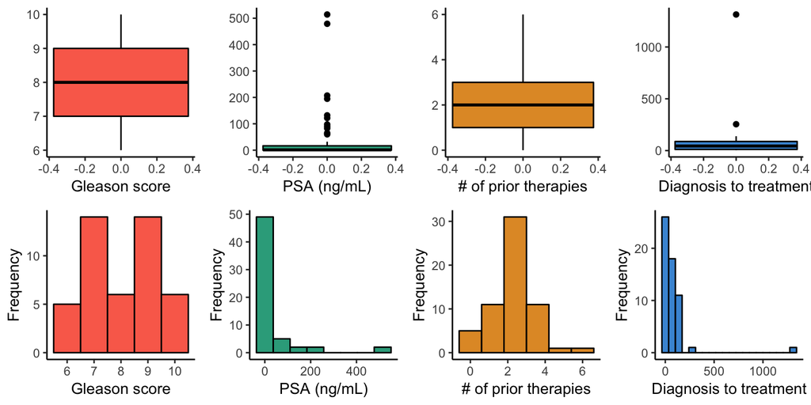

```r
# Checking the distributions of continuous variables
colors <- c('#FA6E59', '#31A98B', '#E29930', '#4897D8')

p1 <- ggplot(data = dat_nepc) + geom_histogram(aes(x = gleason), fill = colors[1], color = "black", bins = 5) + theme_classic() + guides(fill = F) + ylab("Frequency") + xlab("Gleason score")
p2 <- ggplot(data = dat_nepc) + geom_histogram(aes(x = psa), fill = colors[2], color = "black", bins = 8) + theme_classic() + guides(fill = F) + ylab("Frequency") + xlab("PSA (ng/mL)")
p3 <- ggplot(data = dat_nepc) + geom_histogram(aes(x = prtherapy), fill = colors[3], color = "black", bins = 6) + theme_classic() + guides(fill = F) + ylab("Frequency") + xlab("# of prior therapies")
p4 <- ggplot(data = dat_nepc) + geom_histogram(aes(x = intdiag), fill = colors[4], color = "black", bins = 20)+ theme_classic() + guides(fill = F) + ylab("Frequency") + xlab("Diagnosis to treatment")

p5 <- ggplot(dat_nepc) + geom_boxplot(aes(y = gleason), fill = colors[1], color = "black", varwidth = T) + theme_classic() + guides(fill = F) + ylab("") + xlab("Gleason score")
p6 <- ggplot(dat_nepc) + geom_boxplot(aes(y = psa), fill = colors[2], color = "black") + theme_classic() + guides(fill = F) + ylab("") + xlab("PSA (ng/mL)")
p7 <- ggplot(dat_nepc) + geom_boxplot(aes(y = prtherapy), fill = colors[3], color = "black") + theme_classic() + guides(fill = F) + ylab("") + xlab("# of prior therapies")
p8 <- ggplot(dat_nepc) + geom_boxplot(aes(y = intdiag), fill = colors[4], color = "black") + theme_classic() + guides(fill = F) + ylab("") + xlab("Diagnosis to treatment")

grid.arrange(p5, p6, p7, p8, p1, p2, p3, p4, ncol = 4)
```

> - Since the distributions of PSA and Time from initial diagnosis to treatement are right-skewed, the team decided to use Wilcoxon rank sum test instead of t-test.
> - Some continous variables include a number of outliers: `intdiag` and `psa`. However, the team decided to include them because the sample size is small and there are many missing values. Thus, we need to maximize our power to detect the significant difference.
2. Categorical varaibles (including gene abnormalities):
- Non-gene abnormality variables: `NEPC`, `visceral`, `LDHab`, and `prog3mon`
- Genetic mutations: `rb1`, `tp53`, `pten`, `brca2`, `ar`, `aurka`, and `mycn`

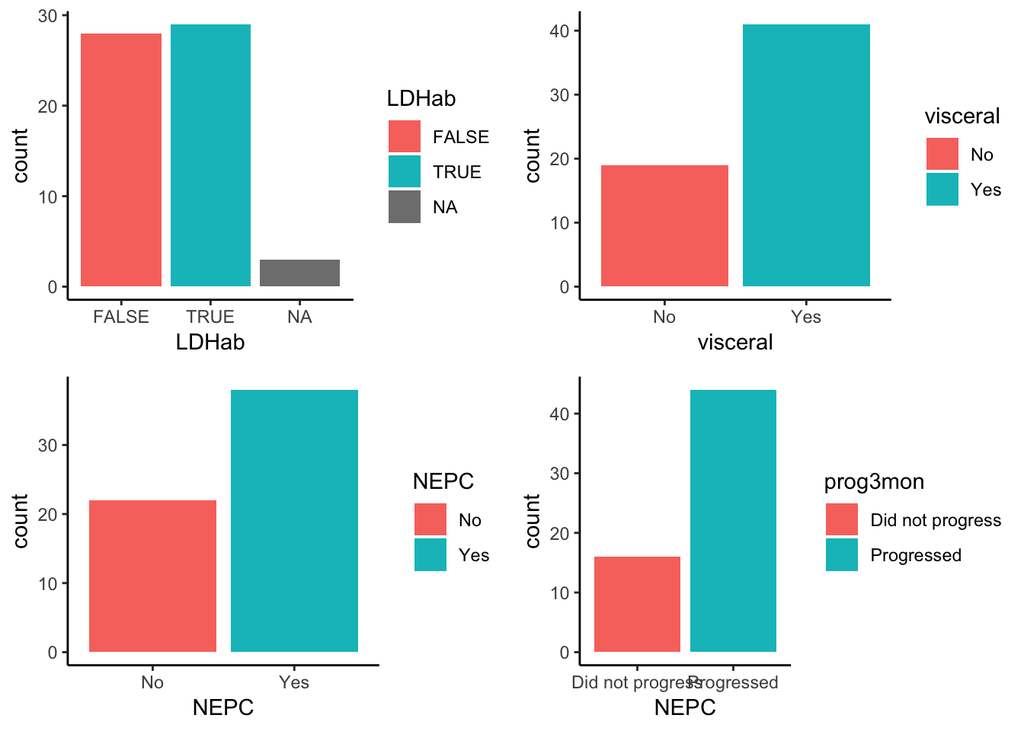

```r
# non-gene abonormality variables
p9 <- ggplot(dat_nepc, aes(x=LDHab,fill=LDHab))+
  geom_bar()+
  xlab("LDHab") + theme_classic()

p10 <- ggplot(dat_nepc, aes(x=visceral,fill=visceral))+
  geom_bar()+
  xlab("visceral") + theme_classic()

p11 <- ggplot(dat_nepc, aes(x=NEPC ,fill=NEPC ))+
  geom_bar()+
  xlab("NEPC") + theme_classic()

p12 <- ggplot(dat_nepc, aes(x=prog3mon ,fill=prog3mon ))+
  geom_bar()+
  xlab("NEPC") + theme_classic()

grid.arrange(p9, p10, p11, p12, ncol=2)
```

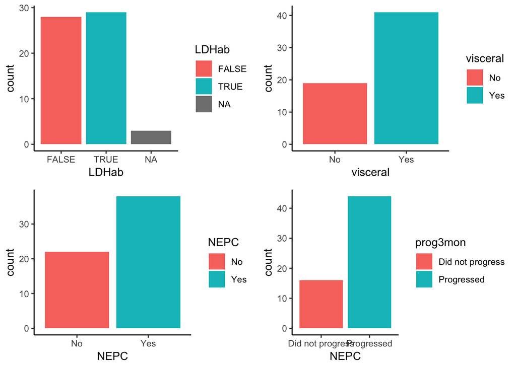

```r
# Genetic mutations
p13 <- ggplot(dat_nepc, aes(x=rb1, fill=rb1))+
  geom_bar()+
  xlab("RB1") + theme_classic()

p14 <- ggplot(dat_nepc, aes(x=tp53,fill=tp53))+
  geom_bar()+
  xlab("TP53") + theme_classic()

p15 <- ggplot(dat_nepc, aes(x=pten ,fill=pten ))+
  geom_bar()+
  xlab("PTEN") + theme_classic()

p16 <- ggplot(dat_nepc, aes(x=brca2 ,fill=brca2 ))+
  geom_bar()+
  xlab("BRCA2") + theme_classic()

p17 <- ggplot(dat_nepc, aes(x=ar ,fill=ar ))+
  geom_bar()+
  xlab("AR") + theme_classic()

p18 <- ggplot(dat_nepc, aes(x=aurka ,fill=aurka ))+
  geom_bar()+
  xlab("AURKA") + theme_classic()

p19 <- ggplot(dat_nepc, aes(x=mycn ,fill=mycn ))+
  geom_bar()+
  xlab("N-MYC") + theme_classic()


grid.arrange(p9, p10, p11, p12, ncol=2)
```

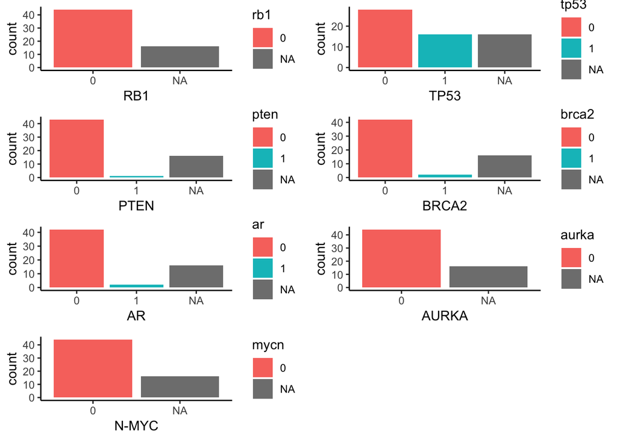

```r
grid.arrange(p13, p14, p15, p16, p17, p18, p19, ncol=2)
```

```r
cat_vars <- dat_nepc %>%
    select(NEPC, visceral, LDHab, prog3mon, rb1, tp53, pten, brca2, ar, aurka, mycn)

observed_table <- function () {
    tab <- list()
    for (i in 1:ncol(cat_vars)) {
        tab[[i]] <-  table(cat_vars[i], useNA = "ifany")
    }
     names(tab) <- c("NEPC", "visceral", "LDHab", "prog3mon",
                    "rb1", "tp53", "pten", "brca2", "ar", "aurka", "mycn")
    tab
}

observed_table()
```

```
## $NEPC
##
##  No Yes
##  22  38
##
## $visceral
##
##  No Yes
##  19  41
##
## $LDHab
##
## FALSE  TRUE  <NA>
##    28    29     3
##
## $prog3mon
##
## Did not progress       Progressed
##               16               44
##
## $rb1
##
##    0 <NA>
##   44   16
##
## $tp53
##
##    0    1 <NA>
##   28   16   16
##
## $pten
##
##    0    1 <NA>
##   43    1   16
##
## $brca2
##
##    0    1 <NA>
##   42    2   16
##
## $ar
##
##    0    1 <NA>
##   42    2   16
##
## $aurka
##
##    0 <NA>
##   44   16
##
## $mycn
##
##    0 <NA>
##   44   16
```

### Question 1

What is the observed 3-month progression free survival rate for men with metastatic prostate cancer treated with alisertib?

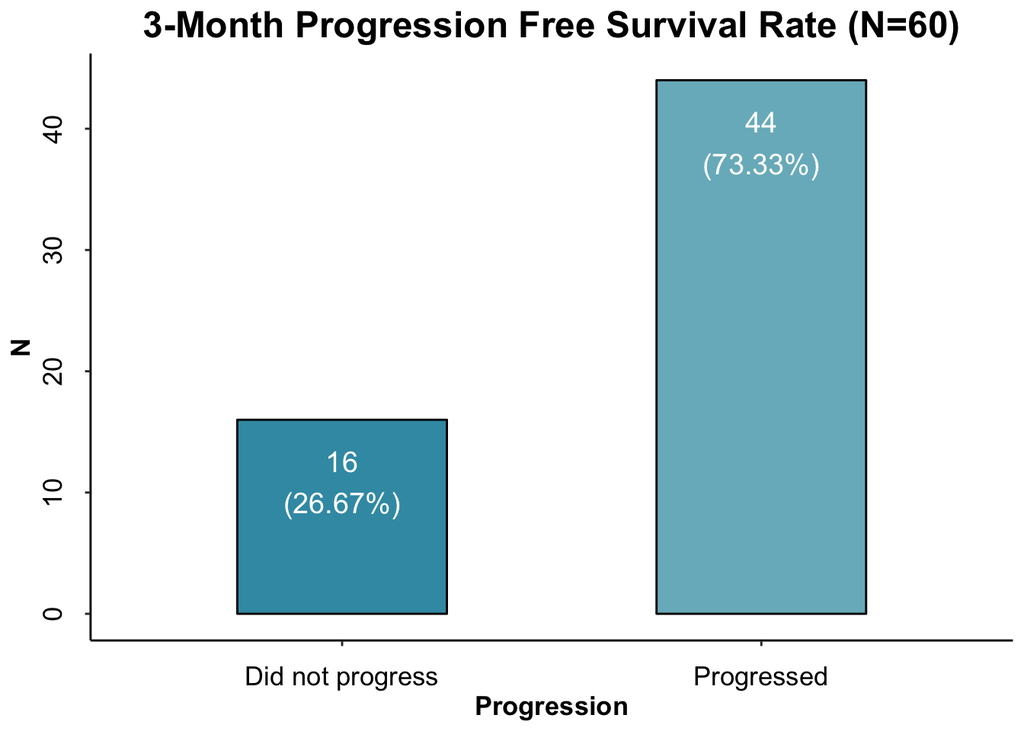

```r
NEPCq1 <- dat_nepc %>%
  select(prog3mon) %>%
  group_by(prog3mon) %>%
  count(.) %>%
  mutate(perc = paste0(n, "\n(",round((n/60)*100,2), "%)"))

ggplot(NEPCq1, aes(x = prog3mon, y = n, fill = prog3mon)) +
    geom_col(width = 0.5, color = 'black') +
    geom_text(aes(label = perc, vjust = 1.5), colour = "white", size = 5) +
    ggtitle("3-Month Progression Free Survival Rate (N=60)") +
    xlab("Progression") +
    ylab("N") +
    guides(fill = FALSE) +
    scale_fill_manual(values = wes_palette(n = 2, name = "Zissou1")) +
    theme_classic() +
    theme(plot.title = element_text(hjust = 0.5, size = 18, face = "bold"),
          axis.text=element_text(size = 13),
          axis.title=element_text(size = 13,face="bold"),
          axis.text.x = element_text(hjust = 0.5,
                                   size = 13,
                                   color = 'black',
                                   margin = margin(10, 0, 0, 0)),
        axis.text.y = element_text(angle = 90,
                                   hjust = 0.5,
                                   size = 13,
                                   color = 'black',
                                   margin = margin(0, 10, 0, 0)))
```

```r
#Confidence interval for the proportion
prog3NO <- sum(dat_nepc$prog3mon=="Did not progress")
prog3LENGTH <- length(dat_nepc$prog3mon)
binom.test(prog3NO,prog3LENGTH, conf.level = .95)$conf.int %>% round(4)
```

```
## [1] 0.1607 0.3966
## attr(,"conf.level")
## [1] 0.95
```

### Question 2

What variables are associated with 3-month progression status?

(With Question 3 altogether)

### Question 3

Is there an association between gene abnormalities and 3 month progression status?

1. Continuous variables:
- `psa` and `intdiag`: Wilcoxon rank sum test
- `gleason` and `prtherapy`: Two sample t-test
- In the Exploratory Data Analysis (EDA) step, according to the boxplots and histograms above, `psa` and `intdiag` are right-skewed, while `gleason` and `prtherapy` has some skewness but not that extreme.
- Hence Wilcoxon rank sum test has been conducted for `psa` and `intdiag`.
- Here, just in case, we plotted the boxplots by `prog3mon` to double-check.

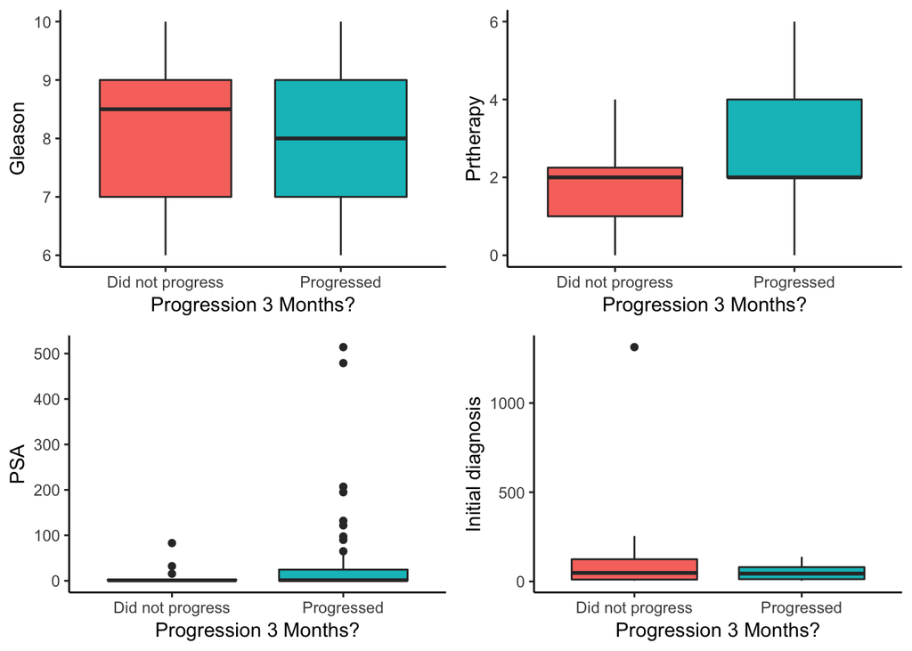

```r
# Boxplots by 3-month progression status just in case
gleason.box <- dat_nepc %>%
  ggplot(aes(y=gleason, x=prog3mon,fill=prog3mon))+
  geom_boxplot()+
  guides(fill=FALSE)+
  ylab("Gleason")+
  xlab("Progression 3 Months?") + theme_classic()

prtherapy.box <-dat_nepc %>%
  ggplot(aes(y=prtherapy, x=prog3mon,fill=prog3mon))+
  geom_boxplot()+
  guides(fill=FALSE)+
  ylab("Prtherapy")+
  xlab("Progression 3 Months?") + theme_classic()

psa.box <- dat_nepc %>%
  ggplot(aes(y=psa, x=prog3mon,fill=prog3mon))+
  geom_boxplot()+
  guides(fill=FALSE)+
  ylab("PSA")+
  xlab("Progression 3 Months?") + theme_classic()

intdiag.box <- dat_nepc %>%
  ggplot(aes(y=intdiag, x=prog3mon,fill=prog3mon)) +
  geom_boxplot()+
  guides(fill=FALSE)+
  ylab("Initial diagnosis")+
  xlab("Progression 3 Months?") + theme_classic()

grid.arrange(gleason.box,prtherapy.box, psa.box, intdiag.box, nrow = 2)
```

- Testing association for continuous variables:

```r
# psa
wilcox.test(dat_nepc$psa ~ dat_nepc$prog3mon,conf.int=TRUE,correct=F)
```

```
##
##  Wilcoxon rank sum test
##
## data:  dat_nepc$psa by dat_nepc$prog3mon
## W = 318, p-value = 0.5693
## alternative hypothesis: true location shift is not equal to 0
## 95 percent confidence interval:
##  -4.9999606  0.3299678
## sample estimates:
## difference in location
##             -0.1289413
```

```r
# intdiag
wilcox.test(dat_nepc$intdiag ~ dat_nepc$prog3mon,conf.int=TRUE,correct=F)
```

```
##
##  Wilcoxon rank sum test
##
## data:  dat_nepc$intdiag by dat_nepc$prog3mon
## W = 346, p-value = 0.7584
## alternative hypothesis: true location shift is not equal to 0
## 95 percent confidence interval:
##  -17.60656  39.83607
## sample estimates:
## difference in location
##               2.557377
```

```r
# gleason
t.test(dat_nepc$gleason ~ dat_nepc$prog3mon)
```

```
##
##  Welch Two Sample t-test
##
## data:  dat_nepc$gleason by dat_nepc$prog3mon
## t = 0.4022, df = 21.547, p-value = 0.6915
## alternative hypothesis: true difference in means is not equal to 0
## 95 percent confidence interval:
##  -0.6937693  1.0271026
## sample estimates:
## mean in group Did not progress       mean in group Progressed
##                       8.166667                       8.000000
```

```r
# prtherapy
t.test(dat_nepc$prtherapy ~ dat_nepc$prog3mon)
```

```
##
##  Welch Two Sample t-test
##
## data:  dat_nepc$prtherapy by dat_nepc$prog3mon
## t = -1.9877, df = 32.821, p-value = 0.05524
## alternative hypothesis: true difference in means is not equal to 0
## 95 percent confidence interval:
##  -1.39134912  0.01634912
## sample estimates:
## mean in group Did not progress       mean in group Progressed
##                         1.8125                         2.5000
```

2. Categorical variables
- Chi-square test: `LDHab`, `visceral`, and `NEPC`
- Fisher’s exact test: `tp53`, `pten`, `brca2`, and `ar`
- Test not applicable (due to no occurences of genetic mutations): `rb1`, `aurka`, and `mycn`
- Looking at the expected tables, it looks like we will need to use Fisher’s exact test for all the gene abnormalities that we can test because all expected tables have a cell that is < 5.
- Testing association for categorical variables:

```r
# Expected table
chisq.test(table(dat_nepc$prog3mon,dat_nepc$LDHab))$expected %>% round #chi-square
```

```
##
##                    FALSE TRUE
##   Did not progress     7    8
##   Progressed          21   21
```

```r
chisq.test(table(dat_nepc$prog3mon,dat_nepc$visceral))$expected %>% round #chi-square
```

```
##
##                    No Yes
##   Did not progress  5  11
##   Progressed       14  30
```

```r
chisq.test(table(dat_nepc$prog3mon,dat_nepc$NEPC))$expected %>% round #chi-square
```

```
##
##                    No Yes
##   Did not progress  6  10
##   Progressed       16  28
```

```r
chisq.test(table(dat_nepc$prog3mon,dat_nepc$LDHab),correct=FALSE, na.action(na.exclude))
```

```
##
##  Pearson's Chi-squared test
##
## data:  table(dat_nepc$prog3mon, dat_nepc$LDHab)
## X-squared = 0.96371, df = 1, p-value = 0.3263
```

```r
chisq.test(table(dat_nepc$prog3mon,dat_nepc$visceral),correct=FALSE, na.action(na.exclude))
```

```
##
##  Pearson's Chi-squared test
##
## data:  table(dat_nepc$prog3mon, dat_nepc$visceral)
## X-squared = 3.389, df = 1, p-value = 0.06563
```

```r
chisq.test(table(dat_nepc$prog3mon,dat_nepc$NEPC),correct=FALSE, na.action(na.exclude))
```

```
##
##  Pearson's Chi-squared test
##
## data:  table(dat_nepc$prog3mon, dat_nepc$NEPC)
## X-squared = 0.27566, df = 1, p-value = 0.5996
```

```r
#Use `prop.test()` to get the confidence intervals
prop.test(c(9,6),c(28,29),correct=F)$conf.int #LDH
```

```
## [1] -0.1127563  0.3418203
## attr(,"conf.level")
## [1] 0.95
```

```r
prop.test(c(8,8),c(19,41),correct=F)$conf.int #Visceral
```

```
## [1] -0.02705149  0.47891285
## attr(,"conf.level")
## [1] 0.95
```

```r
prop.test(c(5,11),c(22,38),correct=F)$conf.int #NEPC
```

```
## [1] -0.2890435  0.1646416
## attr(,"conf.level")
## [1] 0.95
```

```r
#Trying out Mosaic plot - could work for visualization
#mosaicplot(table(dat_nepc$prog3mon,dat_nepc$visceral), shade=TRUE)
#mosaicplot(table(dat_nepc$prog3mon,dat_nepc$LDHab), shade=TRUE)
```

#### Comprehensive Table One for Q2 and Q3

```r
# plus-minus symbol
pm = " ± "

# a function for showing p-value as "<0.001" if the p-value is too small to show.
p.output <- function(p) {
  if(p < 0.001) p.txt <- "<0.001"
  else p.txt <- round(p, 2)
  p.txt
}

# observed table and expected table
exptvalue <- function(table) {
    rowss <- rowSums(table)
    colss <- colSums(table)

    new <- matrix(nrow=nrow(table), ncol=ncol(table))

    for (i in 1:nrow(table)){
        for (j in 1:ncol(table)) {
            new[i,j] <- rowss[i]*colss[j]/sum(table)
        }
    }

    colnames(new) <- colnames(table)
    rownames(new) <- rownames(table)
    new
 }

# Continuous varaibles: `gleason`, `prtherapy` == t-test and `psa`, `intdiag` == 'Wilcoxon rank sum test`
contin <- function(data = dat_nepc,
                   x, realx,
                   y = prog3mon, realy = dat_nepc$prog3mon) {
  xx <- enquo(x)
  yy <- enquo(y)

  t2 <- data %>%
    group_by(!!yy) %>%
    summarise(mean = mean(!!xx, na.rm = T),
              sd = sd(!!xx, na.rm = T),
              median=median(!!xx, na.rm = T),
              min = min(!!xx, na.rm = T),
              max = max(!!xx, na.rm = T))

  t2.1 <- matrix(nrow = 3, ncol = 2)

  for (i in 1:2) {
    t2.1[1,i] <- ""
    t2.1[2,i] <- paste0(round(t2$mean[i], 1), pm, round(t2$sd[i], 1))
    t2.1[3,i] <- paste0(round(t2$median[i], 1),
                        " (", round(t2$min[i], 1),", ",
                        round(t2$max[i],1), ")")}

  xvar <- as.character(deparse(substitute(realx)))
  quote_x <- gsub(".*\\$","", xvar)

  if (quote_x %in% c("gleason","prtherapy")) {
    p <- t.test(realx ~ realy)$p.value
    p <- c(paste0(p.output(p), "****") , "", "")
  }

  else{
    p <- wilcox.test(realx ~ realy)$p.value
    p <- c(paste0(p.output(p), "*****") , "", "")
  }

  name <- c(xvar,
            paste0("  Mean", pm, "SD"),
            "  Median (min, max)")
  t <- cbind(name, t2.1, p)
  t
}

# Categorical variables
categ <- function(data = dat_nepc, x, realx,
                  realy = dat_nepc$prog3mon) {
  xx <- enquo(x)

  t2 <- table(realx, realy)

  CPC <- round(prop.table(t2, 2) * 100, 1)
  t2.1 <- matrix(ncol = length(levels(realy)),
                 nrow = length(levels(realx)))

  for (j in 1:length(levels(realy))) {
    for (i in 1:length(levels(realx))) {
      t2.1[i,j] <- paste0(t2[i,j]," (",CPC[i,j], "%)")
    }
  }

  t <- rbind("", cbind("", t2.1))
  xvar <- as.character(deparse(substitute(realx)))
  quote_x <- gsub(".*\\$","", xvar)
  t[ ,1] <- c(quote_x, rep("", length(levels(realx))))

  for (i in 1:length(levels(realx))) {
    t[i+1, 1] <- paste0("  ",as.character(levels(realx)[i]))
  }

  exp.t <- exptvalue(t2)
  if (nrow(exp.t)==1){
    c <- ".*"
  }

  else if (sum(exp.t<5) >= 1) {
    c <- fisher.test(t2)$p.value
    c <- paste0(p.output(c), "**")
  }

  else {
    c <- chisq.test(t2)$p.value
    c <- paste0(p.output(c), "***")
  }

  cbind(t, c(c, rep("", length(levels(realx)))))
}

# Binding
table.bind <- rbind(contin(x = gleason, realx = dat_nepc$gleason),
      contin(x = psa, realx = dat_nepc$psa),
      contin(x = prtherapy, realx = dat_nepc$prtherapy),
      categ(x = NEPC, realx = dat_nepc$NEPC),
      contin(x = intdiag, realx = dat_nepc$intdiag),
      categ(x = visceral, realx = dat_nepc$visceral),
      categ(x = LDHab, realx = dat_nepc$LDHab),
      categ(x = rb1, realx = dat_nepc$rb1),
      categ(x = tp53, realx = dat_nepc$tp53),
      categ(x = pten, realx = dat_nepc$pten),
      categ(x = brca2, realx = dat_nepc$brca2),
      categ(x = ar, realx = dat_nepc$ar),
      categ(x = aurka, realx = dat_nepc$aurka),
      categ(x = mycn, realx = dat_nepc$mycn)
      )

colnames(table.bind) <- c("Characteristics",
                          paste0("Not Progressed, N=", sum(dat_nepc$prog3mon == "Did not progress")),
                          paste0("Progressed, N=", sum(dat_nepc$prog3mon == "progressed")), "p-value")

table.bind[ ,1][c(1, 4, 7, 10, 13, 16, 19, 22, 24, 27, 30, 33, 36, 38)] <- c("Gleason score at baseline (from 1-10)", "PSA at baseline (ng/mL)", "Number of priror systemic therapies (integer)", "NEPC status", "Time from diagnosis to study start (months)", "Visceral disease status", "Elevated LDH level at baseline", "RB1", "TP53", "PTEN", "BRCA2", "AR ", "AURKA", "MYCN")
table.bind[ ,1][c(20, 21, 23, 25, 26, 28, 29, 31, 32, 34, 35, 37, 39)] <- c("  No", "  Yes", "  No", "  No", "  Yes", "  No", "  Yes", "  No", "  Yes", "  No", "  Yes", "  No", "  No")

vec <- 1:39
indent <- vec[-c(1, 4, 7, 10, 13, 16, 19, 22, 24, 27, 30, 33, 36, 38)]
knitr::kable(table.bind, align=c("l", "c", "c", "r"), booktabs = T,
             caption = "3-Month Progression Status and Patient Characteristics (N=60)") %>%
    add_indent(.,indent) %>% row_spec(0, bold = TRUE) %>%
    footnote(general = "Since there is no TRUE or YES values, any test was not employed.",
             general_title = "*", footnote_as_chunk = T) %>%
    footnote(general = "Fisher's exact test was used to generate p-value.",
             general_title = "**", footnote_as_chunk = T) %>%
    footnote(general = "Chi-square test was used to generate p-value.",
             general_title = "***", footnote_as_chunk = T) %>%
    footnote(general = "T-test was used to generate p-value.",
             general_title = "****", footnote_as_chunk = T) %>%
    footnote(general = "Wilcoxon rank sum test was used to generate p-value.",
             general_title = "*****", footnote_as_chunk = T)
```

3-Month Progression Status and Patient Characteristics (N=60)

| Characteristics | Not Progressed, N=16 | Progressed, N=0 | p-value |
| --- | --- | --- | --- |
| Gleason score at baseline (from 1-10) |  |  | 0.69**** |
| Mean ± SD | 8.2 ± 1.2 | 8 ± 1.3 |  |
| Median (min, max) | 8.5 (6, 10) | 8 (6, 10) |  |
| PSA at baseline (ng/mL) |  |  | 0.58***** |
| Mean ± SD | 8.9 ± 21.5 | 47.2 ± 111.7 |  |
| Median (min, max) | 0.9 (0, 83) | 1.3 (0, 514.2) |  |
| Number of priror systemic therapies (integer) |  |  | 0.06**** |
| Mean ± SD | 1.8 ± 1.1 | 2.5 ± 1.4 |  |
| Median (min, max) | 2 (0, 4) | 2 (0, 6) |  |
| NEPC status |  |  | 0.82*** |
| No | 5 (31.2%) | 17 (38.6%) |  |
| Yes | 11 (68.8%) | 27 (61.4%) |  |
| Time from diagnosis to study start (months) |  |  | 0.76***** |
| Mean ± SD | 141.9 ± 319.8 | 52.3 ± 41.9 |  |
| Median (min, max) | 48 (4, 1313.4) | 44.2 (3.9, 138) |  |
| Visceral disease status |  |  | 0.13*** |
| No | 8 (50%) | 11 (25%) |  |
| Yes | 8 (50%) | 33 (75%) |  |
| Elevated LDH level at baseline |  |  | 0.5*** |
| No | 9 (60%) | 19 (45.2%) |  |
| Yes | 6 (40%) | 23 (54.8%) |  |
| RB1 |  |  | .* |
| No | 11 (100%) | 33 (100%) |  |
| TP53 |  |  | 0.28** |
| No | 9 (81.8%) | 19 (57.6%) |  |
| Yes | 2 (18.2%) | 14 (42.4%) |  |
| PTEN |  |  | 1** |
| No | 11 (100%) | 32 (97%) |  |
| Yes | 0 (0%) | 1 (3%) |  |
| BRCA2 |  |  | 0.06** |
| No | 9 (81.8%) | 33 (100%) |  |
| Yes | 2 (18.2%) | 0 (0%) |  |
| AR |  |  | 1** |
| No | 11 (100%) | 31 (93.9%) |  |
| Yes | 0 (0%) | 2 (6.1%) |  |
| AURKA |  |  | .* |
| No | 11 (100%) | 33 (100%) |  |
| MYCN |  |  | .* |
| No | 11 (100%) | 33 (100%) |  |

* Since there is no TRUE or YES values, any test was not employed.  
** Fisher’s exact test was used to generate p-value.  
*** Chi-square test was used to generate p-value.  
**** T-test was used to generate p-value.  
***** Wilcoxon rank sum test was used to generate p-value.

#### Point estimates and confidence intervals for Q2 and Q3

Three-month progression free survival status with Patient Characteristics and Gene abnormalities (N=60)

[output not shown]

* Fisher’s exact test - the corresponding point estimate is the odds ratio ** Chi-squared test of proportions - the corresponding point estimate is difference in the proportions of the two groups *** T-test of significance without continuity correction - the corresponding point estimate is the difference in the means of the two groups **** Wilcoxon-rank sum test without continuity correction - the corresponding point estimate is the difference in location

### Question 4

Are there different gene abnormalities and other variables associated with NEPC?

- Just like Q2 and Q3, first, we plotted the boxplots for continuous varaibles by NEPC just in case.

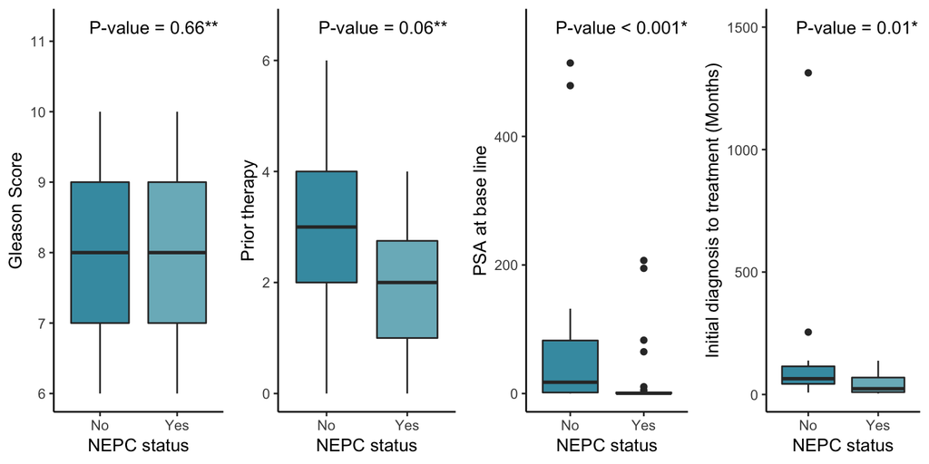

```r
# Boxplots by NEPC
  psa<-ggplot()+geom_boxplot(data = dat_nepc, aes(y=psa, x=NEPC, fill=NEPC), na.rm = TRUE)+
  labs(x="NEPC status",y="PSA at base line")+guides(fill=FALSE)+
  theme(axis.line = element_line(colour = "black"))+
  theme(panel.background =element_blank())+
  scale_fill_manual(values=c("#429AB0","#7AB7C4"))+
  annotate("text", x=1.7,y=570,label = c("P-value < 0.001*"), color = "black")

int<-ggplot()+geom_boxplot(data = dat_nepc, aes(y=intdiag, x=NEPC, fill=NEPC), na.rm = TRUE)+
  labs(x="NEPC status",y="Initial diagnosis to treatment (Months)")+guides(fill=FALSE)+
  theme(axis.line = element_line(colour = "black"))+
  theme(panel.background =element_blank())+
  scale_fill_manual(values=c("#429AB0","#7AB7C4"))+
  annotate("text", x=1.7,y=1500,label = c("P-value = 0.01*"), color = "black")

prtherapy<-ggplot()+geom_boxplot(data = dat_nepc, aes(y=prtherapy, x=NEPC, fill=NEPC), na.rm = TRUE)+
  labs(x="NEPC status",y="Prior therapy")+guides(fill=FALSE)+
  theme(axis.line = element_line(colour = "black"))+
  theme(panel.background =element_blank())+
  scale_fill_manual(values=c("#429AB0","#7AB7C4"))+
  annotate("text", x=1.7,y=6.6,label = c("P-value = 0.06**"), color = "black")

gleason<-ggplot()+geom_boxplot(data = dat_nepc, aes(y=gleason, x=NEPC, fill=NEPC), na.rm = TRUE)+
  labs(x="NEPC status",y="Gleason Score")+guides(fill=FALSE)+
  theme(axis.line = element_line(colour = "black"))+
  theme(panel.background =element_blank())+
  scale_fill_manual(values=c("#429AB0","#7AB7C4"))+
  annotate("text", x=1.7,y=11.2,label = c("P-value = 0.66**"), color = "black")

grid.arrange(gleason,prtherapy,psa,int,ncol=4)
```

1. Continuous variables:
- Testing association for continuous variables:

```r
# psa
wilcox.test(dat_nepc$psa ~ dat_nepc$NEPC)
```

```
##
##  Wilcoxon rank sum test with continuity correction
##
## data:  dat_nepc$psa by dat_nepc$NEPC
## W = 656.5, p-value = 0.0002569
## alternative hypothesis: true location shift is not equal to 0
```

```r
# intdiag
wilcox.test(dat_nepc$intdiag ~ dat_nepc$NEPC)
```

```
##
##  Wilcoxon rank sum test
##
## data:  dat_nepc$intdiag by dat_nepc$NEPC
## W = 519, p-value = 0.006868
## alternative hypothesis: true location shift is not equal to 0
```

```r
# gleason
t.test(dat_nepc$gleason ~ dat_nepc$NEPC)
```

```
##
##  Welch Two Sample t-test
##
## data:  dat_nepc$gleason by dat_nepc$NEPC
## t = -0.44302, df = 42.028, p-value = 0.66
## alternative hypothesis: true difference in means is not equal to 0
## 95 percent confidence interval:
##  -0.9443888  0.6043888
## sample estimates:
##  mean in group No mean in group Yes
##              7.95              8.12
```

```r
# prtherapy
t.test(dat_nepc$prtherapy ~ dat_nepc$NEPC)
```

```
##
##  Welch Two Sample t-test
##
## data:  dat_nepc$prtherapy by dat_nepc$NEPC
## t = 1.911, df = 34.403, p-value = 0.06437
## alternative hypothesis: true difference in means is not equal to 0
## 95 percent confidence interval:
##  -0.04536775  1.48555914
## sample estimates:
##  mean in group No mean in group Yes
##          2.772727          2.052632
```

- Testing association for categorical variables:

```r
# Expected values
chisq.test(table(dat_nepc$NEPC,dat_nepc$LDHab))$expected #use chi-square
```

```
##
##          FALSE     TRUE
##   No  10.31579 10.68421
##   Yes 17.68421 18.31579
```

```r
chisq.test(table(dat_nepc$NEPC,dat_nepc$visceral))$expected #use chi-square
```

```
##
##              No      Yes
##   No   6.966667 15.03333
##   Yes 12.033333 25.96667
```

```r
chisq.test(table(dat_nepc$NEPC,dat_nepc$prog3mon))$expected #use chi-square
```

```
##
##       Did not progress Progressed
##   No          5.866667   16.13333
##   Yes        10.133333   27.86667
```

```r
#LDHab
chisq.test(table(dat_nepc$NEPC,dat_nepc$LDHab)) #use chi-square
```

```
##
##  Pearson's Chi-squared test with Yates' continuity correction
##
## data:  table(dat_nepc$NEPC, dat_nepc$LDHab)
## X-squared = 0.20077, df = 1, p-value = 0.6541
```

```r
#visceral
chisq.test(table(dat_nepc$NEPC,dat_nepc$visceral)) #use chi-square
```

```
##
##  Pearson's Chi-squared test with Yates' continuity correction
##
## data:  table(dat_nepc$NEPC, dat_nepc$visceral)
## X-squared = 0.7798, df = 1, p-value = 0.3772
```

```r
#prog3mon
chisq.test(table(dat_nepc$NEPC,dat_nepc$prog3mon)) #use chi-square
```

```
##
##  Pearson's Chi-squared test with Yates' continuity correction
##
## data:  table(dat_nepc$NEPC, dat_nepc$prog3mon)
## X-squared = 0.049342, df = 1, p-value = 0.8242
```

- Testing association for genetic mutations:

```r
# Eexpected tables
chisq.test(table(dat_nepc$NEPC,dat_nepc$tp53))$expected #use chi-square
```

```
##
##              0        1
##   No  10.81818 6.181818
##   Yes 17.18182 9.818182
```

```r
chisq.test(table(dat_nepc$NEPC,dat_nepc$pten))$expected #use fisher-test
```

```
##
##              0         1
##   No  16.61364 0.3863636
##   Yes 26.38636 0.6136364
```

```r
chisq.test(table(dat_nepc$NEPC,dat_nepc$brca2))$expected #use fisher-test
```

```
##
##              0         1
##   No  16.22727 0.7727273
##   Yes 25.77273 1.2272727
```

```r
chisq.test(table(dat_nepc$NEPC,dat_nepc$ar))$expected #use fisher-test
```

```
##
##              0         1
##   No  16.22727 0.7727273
##   Yes 25.77273 1.2272727
```

```r
# tp53
chisq.test(table(dat_nepc$NEPC,dat_nepc$tp53))
```

```
##
##  Pearson's Chi-squared test with Yates' continuity correction
##
## data:  table(dat_nepc$NEPC, dat_nepc$tp53)
## X-squared = 0.19258, df = 1, p-value = 0.6608
```

```r
# pten
fisher.test(table(dat_nepc$NEPC,dat_nepc$pten))
```

```
##
##  Fisher's Exact Test for Count Data
##
## data:  table(dat_nepc$NEPC, dat_nepc$pten)
## p-value = 0.3864
## alternative hypothesis: true odds ratio is not equal to 1
## 95 percent confidence interval:
##   0.00000 24.55569
## sample estimates:
## odds ratio
##          0
```

```r
# brca2
fisher.test(table(dat_nepc$NEPC,dat_nepc$brca2))
```

```
##
##  Fisher's Exact Test for Count Data
##
## data:  table(dat_nepc$NEPC, dat_nepc$brca2)
## p-value = 0.5148
## alternative hypothesis: true odds ratio is not equal to 1
## 95 percent confidence interval:
##  0.1178396       Inf
## sample estimates:
## odds ratio
##        Inf
```

```r
# ar
fisher.test(table(dat_nepc$NEPC,dat_nepc$ar))
```

```
##
##  Fisher's Exact Test for Count Data
##
## data:  table(dat_nepc$NEPC, dat_nepc$ar)
## p-value = 0.1438
## alternative hypothesis: true odds ratio is not equal to 1
## 95 percent confidence interval:
##  0.000000 3.287877
## sample estimates:
## odds ratio
##          0
```

#### Comprehensive Table One for Q4

```r
# plus-minus symbol
pm = " ± "

# a function for showing p-value as "<0.001" if the p-value is too small to show.
p.output <- function(p) {
  if(p < 0.001) p.txt <- "<0.001"
  else p.txt <- round(p, 2)
  p.txt
}

# observed table to expected table
exptvalue <- function(table) {
    rowss <- rowSums(table)
    colss <- colSums(table)

    new <- matrix(nrow=nrow(table), ncol=ncol(table))

    for (i in 1:nrow(table)){
        for (j in 1:ncol(table)) {
            new[i,j] <- rowss[i]*colss[j]/sum(table)
        }
    }

    colnames(new) <- colnames(table)
    rownames(new) <- rownames(table)
    new
 }

# Continuous varaibles: `gleason`, `prtherapy` == t-test and `psa`, `intdiag` == 'Wilcoxon rank sum test`
contin <- function(data = dat_nepc,
                   x, realx,
                   y = NEPC, realy = dat_nepc$NEPC) {
  xx <- enquo(x)
  yy <- enquo(y)

  t2 <- data %>%
    group_by(!!yy) %>%
    summarise(mean=mean(!!xx, na.rm = T),
              sd = sd(!!xx, na.rm = T),
              median=median(!!xx, na.rm = T),
              min = min(!!xx, na.rm = T),
              max = max(!!xx, na.rm = T))

  t2.1 <- matrix(nrow = 3, ncol = 2)

  for (i in 1:2) {
    t2.1[1,i] <- ""
    t2.1[2,i] <- paste0(round(t2$mean[i], 1), pm, round(t2$sd[i], 1))
    t2.1[3,i] <- paste0(round(t2$median[i], 1),
                        " (", round(t2$min[i], 1),", ",
                        round(t2$max[i],1), ")")}

  xvar <- as.character(deparse(substitute(realx)))
  quote_x <- gsub(".*\\$","", xvar)

  if (quote_x %in% c("gleason","prtherapy")) {
    p <- t.test(realx ~ realy)$p.value
    p <- c(paste0(p.output(p), "****") , "", "")
  }

  else{
    p <- wilcox.test(realx ~ realy)$p.value
    p <- c(paste0(p.output(p), "*****") , "", "")
  }

  name <- c(xvar,
            paste0("  Mean", pm, "SD"),
            "  Median (min, max)")
  t <- cbind(name, t2.1, p)
  t
}

# Categorical variables
categ <- function(data = dat_nepc, x, realx,
                  realy = dat_nepc$NEPC) {
  xx <- enquo(x)

  t2 <- table(realx, realy)

  CPC <- round(prop.table(t2, 2) * 100, 1)
  t2.1 <- matrix(ncol = length(levels(realy)),
                 nrow = length(levels(realx)))

  for (j in 1:length(levels(realy))) {
    for (i in 1:length(levels(realx))) {
      t2.1[i,j] <- paste0(t2[i,j]," (",CPC[i,j], "%)")
    }
  }

  t <- rbind("", cbind("", t2.1))
  xvar <- as.character(deparse(substitute(realx)))
  quote_x <- gsub(".*\\$","", xvar)
  t[ ,1] <- c(quote_x, rep("", length(levels(realx))))

  for (i in 1:length(levels(realx))) {
    t[i+1, 1] <- paste0("  ",as.character(levels(realx)[i]))
  }

  exp.t <- exptvalue(t2)
  if (nrow(exp.t)==1){
    c <- ".*"
  }

  else if (sum(exp.t<5) >= 1) {
    c <- fisher.test(t2)$p.value
    c <- paste0(p.output(c), "**")
  }

  else {
    c <- chisq.test(t2)$p.value
    c <- paste0(p.output(c), "***")
  }

  cbind(t, c(c, rep("", length(levels(realx)))))
}

table.bind <- rbind(contin(x = gleason, realx = dat_nepc$gleason),
      contin(x = psa, realx = dat_nepc$psa),
      contin(x = prtherapy, realx = dat_nepc$prtherapy),
      contin(x = intdiag, realx = dat_nepc$intdiag),
      categ(x = visceral, realx = dat_nepc$visceral),
      categ(x = LDHab, realx = dat_nepc$LDHab),
      categ(x = prog3mon, realx = dat_nepc$prog3mon),
      categ(x = rb1, realx = dat_nepc$rb1),
      categ(x = tp53, realx = dat_nepc$tp53),
      categ(x = pten, realx = dat_nepc$pten),
      categ(x = brca2, realx = dat_nepc$brca2),
      categ(x = ar, realx = dat_nepc$ar),
      categ(x = aurka, realx = dat_nepc$aurka),
      categ(x = mycn, realx = dat_nepc$mycn)
      )

colnames(table.bind) <- c("Characteristics",
                          paste0("No NEPC, N=", sum(dat_nepc$NEPC == "No")),
                          paste0("NEPC, N=", sum(dat_nepc$NEPC == "Yes")), "p-value")

table.bind[ ,1][c(1, 4, 7, 10, 13, 16, 19, 22, 24, 27, 30, 33, 36, 38)] <- c("Gleason score at baseline (from 1-10)", "PSA at baseline (ng/mL)", "Number of prior systemic therapies (integer)", "Time from diagnosis to study start (months)", "Visceral disease status", "Elevated LDH level at baseline", "Disease progression status at three months", "RB1", "TP53", "PTEN", "BRCA2", "AR", "AURKA", "MYCN")
table.bind[ ,1][c(20, 21, 23, 25, 26, 28, 29, 31, 32, 34, 35, 37, 39)] <- c("  No", "  Yes", "  No", "  No", "  Yes", "  No", "  Yes", "  No", "  Yes", "  No", "  Yes", "  No", "  No")

vec <- 1:39
indent <- vec[-c(1, 4, 7, 10, 13, 16, 19, 22, 24, 27, 30, 33, 36, 38)]
knitr::kable(table.bind, align=c("l", "c", "c", "r"), booktabs = T,
             caption = "NEPC and Patient Characteristics (N=60)") %>%
    add_indent(.,indent) %>%
    row_spec(0, bold = TRUE) %>%
    footnote(general = "Since there is no TRUE or YES values, any test was not employed.",
             general_title = "*", footnote_as_chunk = T) %>%
    footnote(general = "Fisher's exact test was used to generate p-value.",
             general_title = "**", footnote_as_chunk = T) %>%
    footnote(general = "Chi-square test was used to generate p-value.",
             general_title = "***", footnote_as_chunk = T) %>%
    footnote(general = "T-test was used to generate p-value.",
             general_title = "****", footnote_as_chunk = T) %>%
    footnote(general = "Wilcoxon rank sum test was used to generate p-value.",
             general_title = "*****", footnote_as_chunk = T)
```

NEPC and Patient Characteristics (N=60)

| Characteristics | No NEPC, N=22 | NEPC, N=38 | p-value |
| --- | --- | --- | --- |
| Gleason score at baseline (from 1-10) |  |  | 0.66**** |
| Mean ± SD | 8 ± 1.2 | 8.1 ± 1.3 |  |
| Median (min, max) | 8 (6, 10) | 8 (6, 10) |  |
| PSA at baseline (ng/mL) |  |  | <0.001***** |
| Mean ± SD | 74.2 ± 142.9 | 15.5 ± 47.4 |  |
| Median (min, max) | 17.5 (0, 514.2) | 0.3 (0, 207) |  |
| Number of prior systemic therapies (integer) |  |  | 0.06**** |
| Mean ± SD | 2.8 ± 1.5 | 2.1 ± 1.1 |  |
| Median (min, max) | 3 (0, 6) | 2 (0, 4) |  |
| Time from diagnosis to study start (months) |  |  | 0.01***** |
| Mean ± SD | 144.9 ± 288.9 | 43.7 ± 41.9 |  |
| Median (min, max) | 64.5 (8, 1313.4) | 23.6 (3.9, 138) |  |
| Visceral disease status |  |  | 0.38*** |
| No | 9 (40.9%) | 10 (26.3%) |  |
| Yes | 13 (59.1%) | 28 (73.7%) |  |
| Elevated LDH level at baseline |  |  | 0.65*** |
| FALSE | 9 (42.9%) | 19 (52.8%) |  |
| TRUE | 12 (57.1%) | 17 (47.2%) |  |
| Disease progression status at three months |  |  | 0.82*** |
| No | 5 (22.7%) | 11 (28.9%) |  |
| Yes | 17 (77.3%) | 27 (71.1%) |  |
| RB1 |  |  | .* |
| No | 17 (100%) | 27 (100%) |  |
| TP53 |  |  | 0.66*** |
| No | 12 (70.6%) | 16 (59.3%) |  |
| Yes | 5 (29.4%) | 11 (40.7%) |  |
| PTEN |  |  | 0.39** |
| No | 16 (94.1%) | 27 (100%) |  |
| Yes | 1 (5.9%) | 0 (0%) |  |
| BRCA2 |  |  | 0.51** |
| No | 17 (100%) | 25 (92.6%) |  |
| Yes | 0 (0%) | 2 (7.4%) |  |
| AR |  |  | 0.14** |
| No | 15 (88.2%) | 27 (100%) |  |
| Yes | 2 (11.8%) | 0 (0%) |  |
| AURKA |  |  | .* |
| No | 17 (100%) | 27 (100%) |  |
| MYCN |  |  | .* |
| No | 17 (100%) | 27 (100%) |  |

* Since there is no TRUE or YES values, any test was not employed.  
** Fisher’s exact test was used to generate p-value.  
*** Chi-square test was used to generate p-value.  
**** T-test was used to generate p-value.  
***** Wilcoxon rank sum test was used to generate p-value.

#### Point estimates and confidence intervals for Q4

- NEPC with Patient Characteristics and Gene abnormalities (N=60)

[output not shown]

* Fisher’s exact test - the corresponding point estimate is the odds ratio ** Chi-squared test of proportions - the corresponding point estimate is difference in the proportions of the two groups *** T-test of significance without continuity correction - the corresponding point estimate is the difference in the means of the two groups **** Wilcoxon-rank sum test without continuity correction - the corresponding point estimate is the difference in location